# HW5

> 1. Carry out a principal component analysis on the engineer data as follows. Ignore groups and use a correlation matrix based on all 40 observations.

Setup

```r
data = read.csv("pilot.dat", header=F, sep="")
colnames(data) = list("group", "y1", "y2", "y3", "y4", "y5", "y6")
```

Run PCA

```r
pc_data = princomp(data[2:7], cor=TRUE)
summary(pc_data, loadings=TRUE)
```

```
## Importance of components:
##                           Comp.1    Comp.2    Comp.3    Comp.4     Comp.5
## Standard deviation     1.3323392 1.1637937 1.0356884 0.9026604 0.72843175
## Proportion of Variance 0.2958546 0.2257360 0.1787751 0.1357993 0.08843547
## Cumulative Proportion  0.2958546 0.5215906 0.7003657 0.8361650 0.92460045
##                            Comp.6
## Standard deviation     0.67260486
## Proportion of Variance 0.07539955
## Cumulative Proportion  1.00000000
##
## Loadings:
##    Comp.1 Comp.2 Comp.3 Comp.4 Comp.5 Comp.6
## y1  0.402  0.396  0.462  0.393  0.210  0.519
## y2         0.747 -0.175  0.132  0.280 -0.553
## y3  0.385 -0.218 -0.433  0.718 -0.259 -0.186
## y4  0.543 -0.314 -0.107 -0.245  0.707 -0.187
## y5 -0.312 -0.356  0.627  0.399  0.201 -0.428
## y6  0.536  0.106  0.405 -0.306 -0.520 -0.416
```

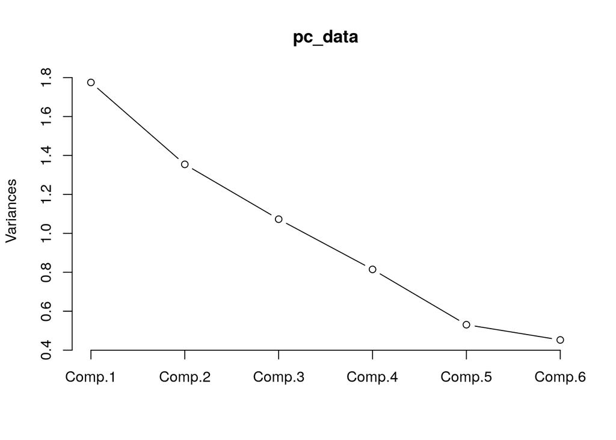

```r
screeplot(pc_data, type="lines")
```

We can see that top four componet contains large variance, and top three component have variance greater than 1.

Also, we can explain the pca data by cutoff

```r
summary(pc_data, loadings=TRUE, cutoff=.5)
```

```
## Importance of components:
##                           Comp.1    Comp.2    Comp.3    Comp.4     Comp.5
## Standard deviation     1.3323392 1.1637937 1.0356884 0.9026604 0.72843175
## Proportion of Variance 0.2958546 0.2257360 0.1787751 0.1357993 0.08843547
## Cumulative Proportion  0.2958546 0.5215906 0.7003657 0.8361650 0.92460045
##                            Comp.6
## Standard deviation     0.67260486
## Proportion of Variance 0.07539955
## Cumulative Proportion  1.00000000
##
## Loadings:
##    Comp.1 Comp.2 Comp.3 Comp.4 Comp.5 Comp.6
## y1                                     0.519
## y2         0.747                      -0.553
## y3                       0.718
## y4  0.543                       0.707
## y5                0.627
## y6  0.536                      -0.520
```

In above data, we can see the pc1 is mainly effect by y4 and y6. And pc2 to pc4 are composed by only one axis.

Then, transform the original data by top 3 loadings of pca.

```r
data_3pc = scale(data[2:7]) %*% pc_data$loadings[, 1:3]
data_3pc
```

```
##            Comp.1      Comp.2      Comp.3
##  [1,] -0.36083524 -1.33966064  0.46535995
##  [2,] -0.17265990 -0.08813300 -0.01153736
##  [3,]  0.12944151  0.69061571 -1.56120118
##  [4,] -3.46091691 -0.93628972  0.12613277
##  [5,] -0.56008002  0.99393556  0.28863957
##  [6,] -1.28671988 -0.19777772  0.52756803
##  [7,] -2.17933041  0.45426659  1.58589273
##  [8,] -0.99346243 -0.89781355  0.96646038
##  [9,]  0.37344060  2.18098560 -0.07677038
## [10,] -1.00471228  0.99242333  0.43954844
## [11,] -0.60093081  0.63145639  0.60461507
## [12,] -0.21094568 -0.08019248 -0.18250412
## [13,] -0.15499300  0.93076469 -0.27235267
## [14,] -1.60670312  0.99597993 -0.53201634
```

[output cut: 26 more lines]

> 2. Use the engineer data. Combine the two groups into a single sample.
> 1. Using a scree plot, the number of eigenvalues greater than 1, and the percentages, is there a clear choice of m?
> 2. Extract three factors by the principal component method and carry out a varimax rotation.
> 3. Extract three factors by the principal factor method and carry out a varimax rotation.
> 4. Compare the results of parts (b) and (c)

## By principal component

```r
library(psych)
data[,2:7] = scale(data[,2:7])
data_cov = cov(data[,2:7])
pfa = principal(data_cov, nfactors=3, rotate="varimax")
pfa
```

```
## Principal Components Analysis
## Call: principal(r = data_cov, nfactors = 3, rotate = "varimax")
## Standardized loadings (pattern matrix) based upon correlation matrix
##      RC3   RC1   RC2   h2   u2 com
## y1 -0.06  0.83  0.17 0.73 0.27 1.1
## y2 -0.35  0.10  0.82 0.81 0.19 1.4
## y3  0.72 -0.03  0.07 0.53 0.47 1.0
## y4  0.74  0.30 -0.19 0.67 0.33 1.5
## y5 -0.49 -0.01 -0.73 0.77 0.23 1.7
## y6  0.24  0.80 -0.07 0.70 0.30 1.2
##
##                        RC3  RC1  RC2
## SS loadings           1.49 1.43 1.28
## Proportion Var        0.25 0.24 0.21
## Cumulative Var        0.25 0.49 0.70
## Proportion Explained  0.36 0.34 0.30
## Cumulative Proportion 0.36 0.70 1.00
##
## Mean item complexity =  1.3
## Test of the hypothesis that 3 components are sufficient.
##
## The root mean square of the residuals (RMSR) is  0.14
##
## Fit based upon off diagonal values = 0.56
```

We can do the same analysis as pca above.

```r
pfa$loadings
```

```
##
## Loadings:
##    RC3    RC1    RC2
## y1         0.834  0.170
## y2 -0.355         0.819
## y3  0.724
## y4  0.738  0.295 -0.195
## y5 -0.486        -0.728
## y6  0.238  0.800
##
##                  RC3   RC1   RC2
## SS loadings    1.492 1.435 1.275
## Proportion Var 0.249 0.239 0.213
## Cumulative Var 0.249 0.488 0.700
```

We can found out

- y3 and y4 and -y5 are correlated.
- y1 and y6 are correlated in pc2.
- y2 and -y5 are correlated in pc3.

## By principle factor

```r
data_fa = fa(data_cov, nfactors=3, rotate="varimax", fm="pa", max.iter=10000)
data_fa
```

```
## Factor Analysis using method =  pa
## Call: fa(r = data_cov, nfactors = 3, rotate = "varimax", max.iter = 10000,
##     fm = "pa")
##
##  Warning: A Heywood case was detected.
## Standardized loadings (pattern matrix) based upon correlation matrix
##      PA1   PA2   PA3   h2    u2 com
## y1  1.55 -0.02  0.08 2.40 -1.40 1.0
## y2  0.13 -0.20 -0.32 0.16  0.84 2.1
## y3  0.04 -0.07  0.32 0.11  0.89 1.1
## y4  0.04 -0.03  0.90 0.81  0.19 1.0
## y5 -0.01  1.48 -0.17 2.21 -1.21 1.0
## y6  0.23 -0.06  0.34 0.17  0.83 1.9
##
##                        PA1  PA2  PA3
## SS loadings           2.46 2.23 1.16
## Proportion Var        0.41 0.37 0.19
## Cumulative Var        0.41 0.78 0.98
## Proportion Explained  0.42 0.38 0.20
## Cumulative Proportion 0.42 0.80 1.00
##
## Mean item complexity =  1.3
## Test of the hypothesis that 3 factors are sufficient.
##
## The degrees of freedom for the null model are  15  and the objective function was  0.68
## The degrees of freedom for the model are 0  and the objective function was  0.01
##
## The root mean square of the residuals (RMSR) is  0.02
## The df corrected root mean square of the residuals is  NA
##
## Fit based upon off diagonal values = 0.99
```

```r
data_fa$loadings
```

```
##
## Loadings:
##    PA1    PA2    PA3
## y1  1.546
## y2  0.135 -0.200 -0.323
## y3                0.316
## y4                0.901
## y5         1.478 -0.165
## y6  0.233         0.335
##
##                  PA1   PA2   PA3
## SS loadings    2.465 2.234 1.162
## Proportion Var 0.411 0.372 0.194
## Cumulative Var 0.411 0.783 0.977
```

We found the factor by principle factor are not normalized. However, it explain much more variance than principle component factor.